# Recipe-Build-a-Dataset-with-APIs

aaron mamula

8/6/2020

## Packages and Data

### Packages

```r
library(RJSONIO) # a package to help parse JSON data returned by the Census API
library(dplyr) # all purpose data wrangling functions/methods
library(data.table) # loaded for the rbindlist() method
library(DT) # makes tables look nice in .Rmd output
library(here)
```

```r
library(tidyr)
library(ggplot2)
library(ggrepel)
```

### Data

```r
api.key <- read.csv(here('data/census-api-key.csv'))
```

## Building a dataset

In `skill-4-Working-with-APIs` I covered the basics of using API calls to get Census Bureau data. Now I’m going to string together several API strings to put together a dataset containing social indicators.

IMHO the real fun with APIs is that you can build data sets programatically. One reason you may want to do somethign like this is to unburden yourself from the demands of maintaining meta-data. Let’s look at an example first then I’ll say a bit more about self-documenting data.

Here, I’m going to build up a small data set of social indicators. Specifically, I’m going to grab the following:

- DP03_0128PE: percent of people in poverty
- DP02_0064PE: percent of population with a bachelor’s degree
- DP04_0134E: median gross rent for renter occupied housing units
- DP03_0062E: median household income

```r
# build a data frame containing identifiers for the data series that I want
series.data <- data.frame(series.name =c('DP02_0001E','DP03_0128PE','DP02_0064PE','DP04_0134E','DP03_0062E'),
                           series.label=c('Total_Households','Percent_in_poverty','Percent_College','Median_Gross_Rent','Median_Income'))
```

### Retreive the Data

```r
# build the API string

# my API key
key <- paste("key=",api.key$key,sep="")

# the base url for Detailed Tables for the 2018 ACS 5-year
base <- "https://api.census.gov/data/2018/acs/acs5/profile?get=NAME,"
# geo parameters
geo <-  "&for=place:*&in=state:06&"

# paste these all together to form the API call for the poverty data series

#create a function to get a clean data frame
data.fn <- function(data.series.name){

  endpoint <- paste(base,data.series.name,geo,key,sep="")

  # get json data
  data <- fromJSON(endpoint)

  # parse json object and coerce to data frame
  data <- tbl_df(data.frame(rbindlist(lapply(data,function(x){
    x<-unlist(x)
    return(data.frame(name=x[1],value=x[2],state=x[3],data_series=data.series.name,
                      data_label=series.data$series.label[which(series.data$series.name==data.series.name)]))
  })
  ))) %>% filter(row_number() > 1)
return(data)
}

indicators <- data.frame(rbindlist(lapply(series.data$series.name,FUN=data.fn)))
# a final step just to clean up the data
indicators <- indicators %>% mutate(value=as.numeric(as.character(value))) %>%
                     mutate(value=ifelse(value<0,NA,value))
```

### Explore the dataset

```r
# National Averages (got these from quick google searches)

# % below poverty line: 12%
# % w/bachelor's degree: 33.4%
# median income/rent ratio:
#     median gross rent: $1,012
#     median monthly gross income: $3,460


# make a data set with national benchmarks
us.df <- data.frame(name=rep('U.S',3),value=c(12,33.4,29.2),
                    data_series=c(1,2,3),data_label=c("Percent_in_poverty","Percent_College","Median_Rent_Income_Ratio"))

# convert to wide format data just to make some plotting easier
indicators.wide <- indicators %>% select(name,value,state,data_label) %>% spread(data_label,value)
head(indicators.wide)
```

```
##                             name state Median_Gross_Rent Median_Income
## 1 Acalanes Ridge CDP, California    06                NA        195481
## 2         Acampo CDP, California    06                NA        141587
## 3          Acton CDP, California    06              1306         96801
## 4      Adelanto city, California    06              1120         40018
## 5           Adin CDP, California    06                NA         56250
## 6  Agoura Hills city, California    06              2327        121896
##   Percent_College Percent_in_poverty Total_Households
## 1            44.3                0.0              287
## 2             7.4                0.0              138
## 3            20.1                8.0             2667
## 4             3.7               35.4             7805
## 5            14.5               26.0               84
## 6            35.0                5.0             7407
```

### Make a Plot

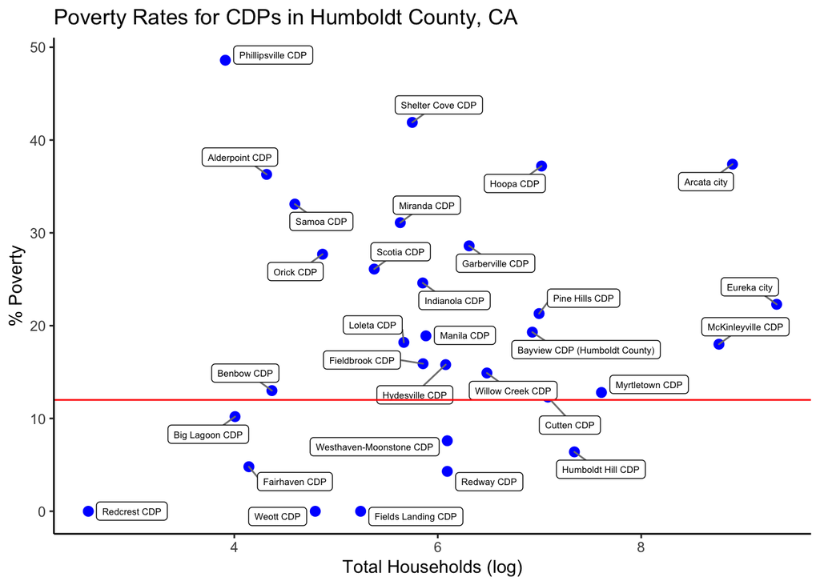

```r
# Census Designated Places in Humboldt County, CA

coastal.communities <- indicators.wide %>% filter(name %in% c('Arcata city, California',
                                                              'Eureka city, California',
                                                              'Fields Landing CDP, California',
                                                              'Alderpoint CDP, California',
                                                              'Bayview CDP (Humboldt County), California',
                                                              'Benbow CDP, California',
                                                              'Big Lagoon CDP, California',
                                                              'Cutten CDP, California',
                                                              'Fairhaven CDP, California',
                                                              'Fieldbrook CDP, California',
                                                              'Garberville CDP, California',
                                                              'Hoopa CDP, California',
                                                              'Humboldt Hill CDP, California',
                                                              'Hydesville CDP, California',
                                                              'Indianola CDP, California',
                                                              'Loleta CDP, California',
                                                              'Manila CDP, California',
                                                              'McKinleyville CDP, California',
                                                              'Miranda CDP, California',
                                                              'Myers Flat CDP, California',
                                                              'Myrtletown CDP, California',
                                                              'Orick CDP, California',
                                                              'Phillipsville CDP, California',
                                                              'Pine Hills CDP, California',
                                                              'Redcrest CDP, California',
                                                              'Redway CDP, California',
                                                              'Samoa CDP, California',
                                                              'Scotia CDP, California',
                                                              'Shelter Cove CDP, California',
                                                              'Weott CDP, California',
                                                              'Westhaven-Moonstone CDP, California',
                                                              'Willow Creek CDP, California'))

coastal.communities$name <- gsub(", California","",coastal.communities$name)

#ggplot(coastal.communities, aes(x= log(Total_Households), y= Percent_in_poverty, label=name))+
#  geom_point() +geom_text(aes(label=name),hjust=0, vjust=0,size=3) +
#  geom_hline(yintercept=us.df$value[which(us.df$data_label=='Percent_in_poverty')],color="red") +
#  theme_bw() + ylab("% Poverty") + xlab("Total Households (log)") +
#  ggtitle("Poverty Rates for CDPs in Humboldt County CA")

ggplot(coastal.communities, aes(x= log(Total_Households), y= Percent_in_poverty, label=name))+
  geom_point(color="blue",size=2.5) +
  geom_label_repel(aes(label=name),
                   size = 2,
                   box.padding = 0.35,
                   segment.color='grey50') +
  geom_hline(yintercept=us.df$value[which(us.df$data_label=='Percent_in_poverty')],color="red")+
  theme_classic() +
  ylab("% Poverty") +
  xlab("Total Households (log)") +
  ggtitle("Poverty Rates for CDPs in Humboldt County, CA")
```